# Setting up windows task scheduler to run R scripts

Stephen J. Price

2020-08-21

# 1 Create a project directory for scripts

1. Right click on the “Task scheduler library” in the left-hand panel
2. Select “New folder…” and create a directory

[figure not shown]

# 2 Click Create task…

1. **General** tab: enter a name and description for task
2. **Triggers** tab: Click “New…”, select “Daily” and then enter a date and time, then set an “Expire” date (usually two weeks for consultations)
3. **Actions** tab:
- click “New…”,
- You want the default action, “Start a program”, which will invoke R from the command prompt
- paste the path to your Rscript.exe into the Program/script box. This will be something like:
  - `"C:\Program Files\R\R-4.0.2\bin\Rscript.exe"` - **you need the inverted commas if there are spaces in your path!!**
- paste the command you need R to run into the “Add arguments” box:
  - `-e "source('O:/DIVISIONAL DRIVES/Standards and Research/Data analytics/Data innovations/Visualisations/Interactive/Consultations/vtq_2021_part2/vtq2021_part2_taskmaster.R')"`
  - again, the inverted commas are needed

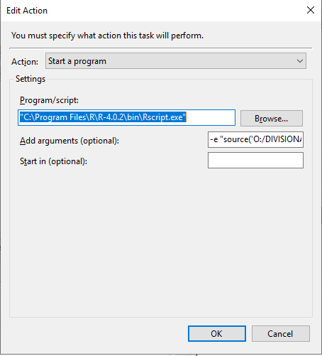

4. **Conditions** tab: uncheck “Start the task only if the computer is on AC power”
5. **Settings** tab: set up as in screenshot (that’s **5** minutes!)

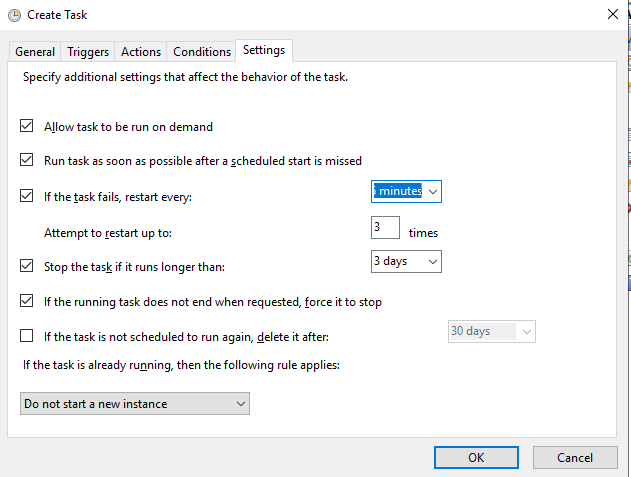

You should be good to go!